# When Every Row Becomes a Curve: Using Andrews Transforms to Turn Multivariate Wine Data into Actionable Quality Intelligence

## Clustering: Curves Know Their Groups

Can the curves recover the cultivar labels *without ever seeing them*? This is the acid test for cultivar authenticity verification.

### Prepare Clean Data

First, we remove wines flagged by two or more outlier methods — they could distort cluster centers.

```r
multi_flagged <- outlier_flags$Wine[outlier_flags$n_methods >= 2]
cat("Removing", length(multi_flagged), "multi-flagged outliers\n")
```

```
Removing 2 multi-flagged outliers
```

```r
if (length(multi_flagged) > 0) {
  keep <- setdiff(1:n, multi_flagged)
  fd_clean <- fd_wine[keep]
  cultivar_clean <- cultivar[keep]
  X_clean <- X[keep, ]
} else {
  fd_clean <- fd_wine
  cultivar_clean <- cultivar
  X_clean <- X
}

cat("Clean dataset:", nrow(fd_clean$data), "wines\n")
```

```
Clean dataset: 176 wines
```

### Functional K-Means

```r
km_fda <- cluster.kmeans(fd_clean, ncl = 3, nstart = 20, seed = 123)

# Confusion matrix with label permutation for optimal matching
conf <- table(Cluster = km_fda$cluster, True = cultivar_clean)

# Try all 6 permutations of labels
best_acc <- 0
best_perm <- NULL
perms <- list(c(1,2,3), c(1,3,2), c(2,1,3), c(2,3,1), c(3,1,2), c(3,2,1))
for (perm in perms) {
  acc <- sum(km_fda$cluster == perm[as.numeric(cultivar_clean)])
  if (acc > best_acc) {
    best_acc <- acc
    best_perm <- perm
  }
}

cat("Confusion matrix:\n")
```

```
Confusion matrix:
```

```r
print(conf)
```

```
       True
Cluster Barolo Grignolino Barbera
      1     59          2       0
      2      0         64       0
      3      0          3      48
```

```r
cat(sprintf("\nBest matching accuracy: %d / %d = %.1f%%\n",
            best_acc, length(cultivar_clean),
            100 * best_acc / length(cultivar_clean)))
```

```
Best matching accuracy: 171 / 176 = 97.2%
```

### Comparison: Standard K-Means on Raw Data

The distance preservation theorem predicts that standard k-means on the original 13 variables should give the same clustering accuracy. Let’s verify — and then examine what each approach gives you *beyond* the cluster assignments.

```r
set.seed(123)
km_raw <- kmeans(X_clean, centers = 3, nstart = 20)

best_acc_raw <- 0
best_perm_raw <- NULL
for (perm in perms) {
  acc <- sum(km_raw$cluster == perm[as.numeric(cultivar_clean)])
  if (acc > best_acc_raw) {
    best_acc_raw <- acc
    best_perm_raw <- perm
  }
}

cat(sprintf("FDA k-means accuracy:  %.1f%%\n",
            100 * best_acc / length(cultivar_clean)))
```

```
FDA k-means accuracy:  97.2%
```

```r
cat(sprintf("Raw k-means accuracy:  %.1f%%\n",
            100 * best_acc_raw / length(cultivar_clean)))
```

```
Raw k-means accuracy:  97.2%
```

Same accuracy — as guaranteed by the distance preservation theorem. So why bother with Andrews curves at all? The difference is in what you can **do with the result** after clustering.

**Standard k-means gives you 13-number centroids.** Each cluster center is a vector of 13 chemical values. To present this to a non-technical audience, you need a table or a parallel coordinate plot — neither of which makes it easy to “see” the differences between cultivars at a glance:

```r
# Standard k-means centers: a table of numbers
raw_center_df <- as.data.frame(round(km_raw$centers, 2))
raw_center_df$Cluster <- paste("Cluster", 1:3)
kable(raw_center_df, caption = "Standard k-means: 13 numbers per cluster center")
```

Standard k-means: 13 numbers per cluster center

| Alcohol | MalicAcid | Ash | Alkalinity | Magnesium | Phenols | Flavanoids | NonflavPhenols | Proanthocyanins | ColorIntensity | Hue | OD280_OD315 | Proline | Cluster |
| --- | --- | --- | --- | --- | --- | --- | --- | --- | --- | --- | --- | --- | --- |
| -0.92 | -0.38 | -0.47 | 0.19 | -0.55 | -0.07 | 0.03 | -0.01 | 0.03 | -0.90 | 0.45 | 0.26 | -0.76 | Cluster 1 |
| 0.86 | -0.30 | 0.38 | -0.62 | 0.51 | 0.89 | 0.99 | -0.56 | 0.54 | 0.19 | 0.47 | 0.79 | 1.13 | Cluster 2 |
| 0.16 | 0.87 | 0.19 | 0.52 | -0.08 | -0.98 | -1.21 | 0.72 | -0.78 | 0.94 | -1.16 | -1.29 | -0.41 | Cluster 3 |

**Functional k-means gives you center *curves*.** Each cluster is represented by a curve that *encodes the same 13 chemicals*, but as a single visual object you can compare, overlay, and present:

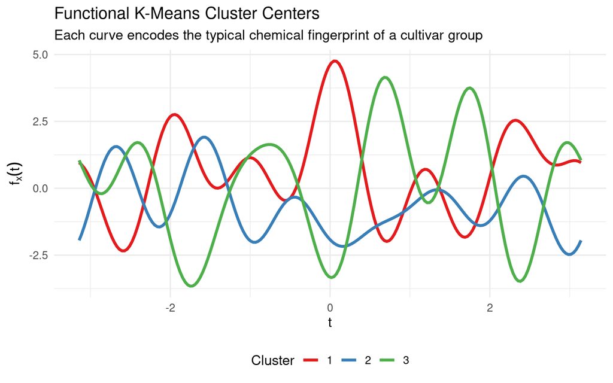

FDA cluster centers as curves — each curve encodes the 13-chemical centroid as a single visual fingerprint.

```r
n_clusters <- nrow(km_fda$centers$data)
df_centers <- data.frame(
  t = rep(t_grid, n_clusters),
  value = as.vector(t(km_fda$centers$data)),
  Cluster = factor(rep(1:n_clusters, each = m))
)

ggplot(df_centers, aes(x = t, y = value, color = Cluster)) +
  geom_line(linewidth = 1.3) +
  scale_color_brewer(palette = "Set1") +
  labs(title = "Functional K-Means Cluster Centers",
       subtitle = "Each curve encodes the typical chemical fingerprint of a cultivar group",
       x = expression(t), y = expression(f[x](t))) +
  theme(legend.position = "bottom")
```

A winemaker looking at this plot immediately sees: cluster 1 and cluster 3 are mirror images (one high where the other is low), while cluster 2 sits in between. That’s the kind of gestalt understanding that a table of 39 numbers can’t deliver. When the certification board asks “how are your cultivars different?”, a single curve overlay answers the question — without requiring the audience to parse a table.

The cluster *assignments* are mathematically identical. The difference is in **communication**: center curves are self-explanatory; center vectors require explanation.

### Fuzzy C-Means: Quantifying Uncertainty

Binary cluster assignments hide important nuance. A wine labeled “Grignolino” that clusters 55% Grignolino / 45% Barbera is a very different story from one that’s 99% Grignolino.

```r
fcm <- cluster.fcm(fd_clean, ncl = 3, seed = 123)

# Identify boundary wines (max membership < 0.6)
max_mem <- apply(fcm$membership, 1, max)
boundary_idx <- which(max_mem < 0.6)

cat(length(boundary_idx), "boundary wines with max membership < 0.6\n")
```

```
25 boundary wines with max membership < 0.6
```

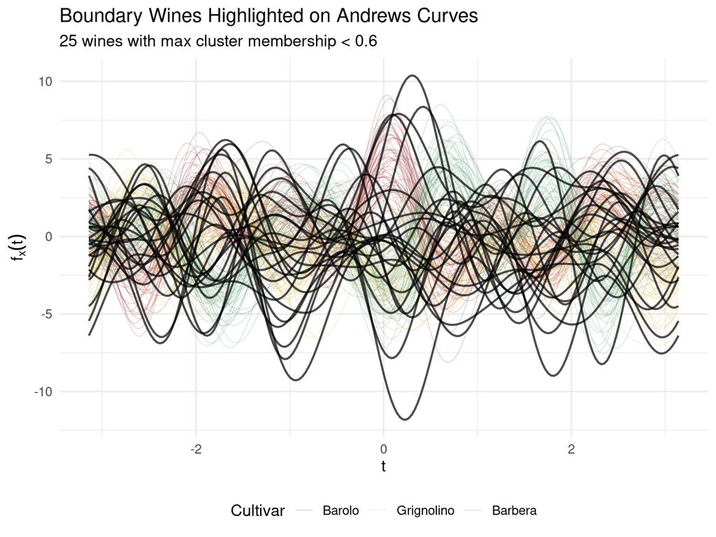

Boundary wines (bold) sit between cultivar clusters — candidates for blend investigation or appellation review.

```r
n_clean <- nrow(fd_clean$data)
is_boundary <- rep(FALSE, n_clean)
is_boundary[boundary_idx] <- TRUE

df_clean_curves <- data.frame(
  t = rep(t_grid, n_clean),
  value = as.vector(t(fd_clean$data)),
  curve = rep(1:n_clean, each = m),
  Cultivar = rep(cultivar_clean, each = m),
  boundary = rep(is_boundary, each = m)
)

ggplot() +
  geom_line(data = filter(df_clean_curves, !boundary),
            aes(x = t, y = value, group = curve, color = Cultivar),
            alpha = 0.2, linewidth = 0.3) +
  geom_line(data = filter(df_clean_curves, boundary),
            aes(x = t, y = value, group = curve),
            color = "black", linewidth = 0.8, alpha = 0.7) +
  scale_color_manual(values = c("Barolo" = "#8B0000",
                                 "Grignolino" = "#DAA520",
                                 "Barbera" = "#2E8B57")) +
  labs(title = "Boundary Wines Highlighted on Andrews Curves",
       subtitle = sprintf("%d wines with max cluster membership < 0.6", length(boundary_idx)),
       x = expression(t), y = expression(f[x](t))) +
  theme(legend.position = "bottom")
```

For a certification body, this quantified uncertainty is far more actionable than a binary classification. Wines with split membership may come from a vineyard on the boundary between appellations, or represent a blend that wasn’t fully declared.

## Do Cultivar Means Really Differ?

Visual separation is suggestive, but for regulatory claims (“our Barolo is chemically distinct”), you need a p-value.

```r
gt <- group.test(fd_wine, cultivar, n.perm = 1000, statistic = "ratio")
cat(sprintf("Permutation test (F-ratio statistic):\n"))
```

```
Permutation test (F-ratio statistic):
```

```r
cat(sprintf("  Observed statistic: %.2f\n", gt$statistic))
```

```
  Observed statistic: 0.78
```

```r
cat(sprintf("  p-value:            %s\n",
            ifelse(gt$p.value == 0,
                   sprintf("< 1/%d = %.4f", gt$n.perm, 1/gt$n.perm),
                   sprintf("%.4f", gt$p.value))))
```

```
  p-value:            < 1/1000 = 0.0010
```

### Bootstrap Confidence Intervals per Cultivar

The permutation test tells us the means differ; the bootstrap CIs show *where* on the chemical profile the cultivars diverge.

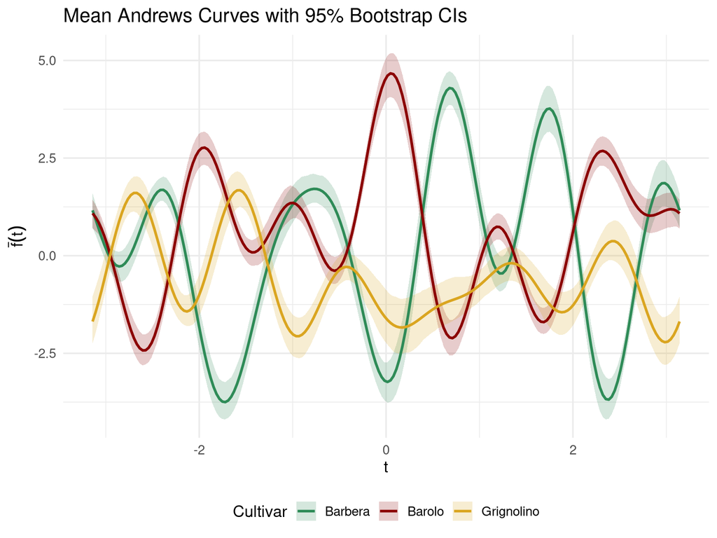

Mean curves with 95% bootstrap CIs — non-overlapping regions identify the Fourier frequencies (and corresponding chemicals) that discriminate cultivars.

```r
cultivar_levels <- levels(cultivar)
ci_list <- list()

for (cv in cultivar_levels) {
  idx <- which(cultivar == cv)
  fd_sub <- fd_wine[idx]

  ci <- fdata.bootstrap.ci(
    fd_sub,
    statistic = function(x) as.numeric(mean(x)$data),
    n.boot = 500,
    seed = 42
  )

  ci_list[[cv]] <- data.frame(
    t = t_grid,
    mean = ci$estimate,
    ci_lower = ci$ci.lower,
    ci_upper = ci$ci.upper,
    Cultivar = cv
  )
}

df_ci <- bind_rows(ci_list)

ggplot(df_ci, aes(x = t, fill = Cultivar, color = Cultivar)) +
  geom_ribbon(aes(ymin = ci_lower, ymax = ci_upper), alpha = 0.2, color = NA) +
  geom_line(aes(y = mean), linewidth = 1) +
  scale_color_manual(values = c("Barolo" = "#8B0000",
                                 "Grignolino" = "#DAA520",
                                 "Barbera" = "#2E8B57")) +
  scale_fill_manual(values = c("Barolo" = "#8B0000",
                                "Grignolino" = "#DAA520",
                                "Barbera" = "#2E8B57")) +
  labs(title = "Mean Andrews Curves with 95% Bootstrap CIs",
       x = expression(t), y = expression(bar(f)(t))) +
  theme(legend.position = "bottom")
```

Regions where the confidence ribbons don’t overlap correspond to Fourier frequencies — and through the Andrews mapping, specific chemicals — that reliably distinguish cultivars. This feeds directly into denomination-of-origin specifications: which chemicals should be tested to verify a wine’s claimed cultivar?

## Which Chemicals Matter Most?

If your lab budget allows testing only 5 of the 13 chemicals, which 5 should you keep? Functional PCA on the Andrews curves answers this.

```r
fpca <- fdata2pc(fd_wine, ncomp = 5)

# Variance explained
var_explained <- fpca$d^2 / sum(fpca$d^2) * 100
cat("Variance explained by first 5 PCs:\n")
```

```
Variance explained by first 5 PCs:
```

```r
for (i in 1:5) {
  cat(sprintf("  PC%d: %.1f%%\n", i, var_explained[i]))
}
```

```
  PC1: 45.0%
  PC2: 24.1%
  PC3: 13.9%
  PC4: 8.8%
  PC5: 8.2%
```

```r
cat(sprintf("  Total (PC1-5): %.1f%%\n", sum(var_explained[1:5])))
```

```
  Total (PC1-5): 100.0%
```

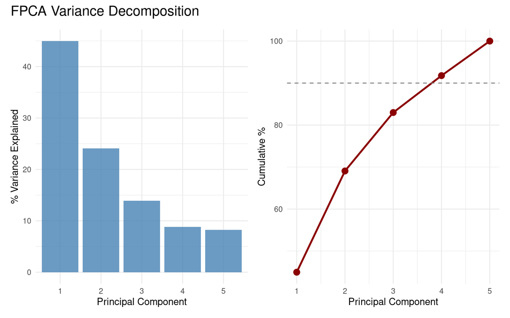

Scree plot — the first two PCs capture the bulk of variation.

```r
df_scree <- data.frame(
  PC = factor(1:5),
  Variance = var_explained[1:5],
  Cumulative = cumsum(var_explained[1:5])
)

p_bar <- ggplot(df_scree, aes(x = PC, y = Variance)) +
  geom_col(fill = "steelblue", alpha = 0.8) +
  labs(y = "% Variance Explained", x = "Principal Component") +
  theme_minimal()

p_cum <- ggplot(df_scree, aes(x = as.numeric(PC), y = Cumulative)) +
  geom_line(linewidth = 1, color = "darkred") +
  geom_point(size = 3, color = "darkred") +
  geom_hline(yintercept = 90, linetype = "dashed", color = "gray50") +
  labs(y = "Cumulative %", x = "Principal Component") +
  scale_x_continuous(breaks = 1:5) +
  theme_minimal()

p_bar + p_cum + plot_annotation(title = "FPCA Variance Decomposition")
```

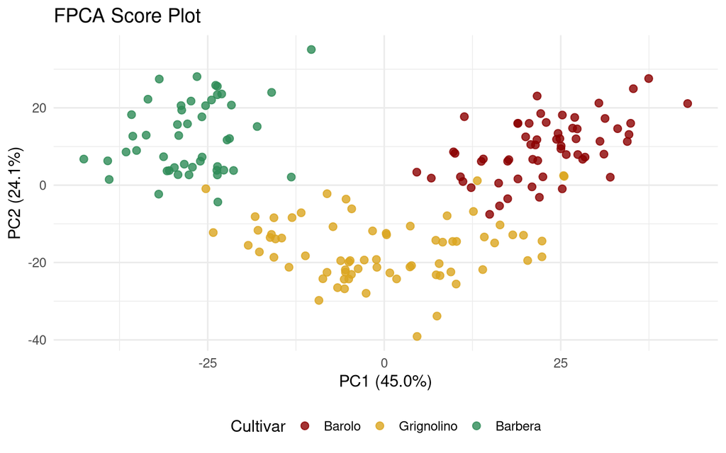

FPCA score plot — cultivars separate cleanly in the first two principal components.

```r
df_scores <- data.frame(
  PC1 = fpca$x[, 1],
  PC2 = fpca$x[, 2],
  Cultivar = cultivar
)

ggplot(df_scores, aes(x = PC1, y = PC2, color = Cultivar)) +
  geom_point(size = 2.5, alpha = 0.8) +
  scale_color_manual(values = c("Barolo" = "#8B0000",
                                 "Grignolino" = "#DAA520",
                                 "Barbera" = "#2E8B57")) +
  labs(title = "FPCA Score Plot",
       x = sprintf("PC1 (%.1f%%)", var_explained[1]),
       y = sprintf("PC2 (%.1f%%)", var_explained[2])) +
  theme(legend.position = "bottom")
```

### Projecting Back to Original Variables

The FPCA eigenfunctions live in Fourier space. To identify which of the 13 original chemicals drive each PC, we project each eigenfunction back onto the Andrews basis vectors. The inner product of an eigenfunction with the $j$-th basis function gives the “loading” of variable $j$ on that PC.

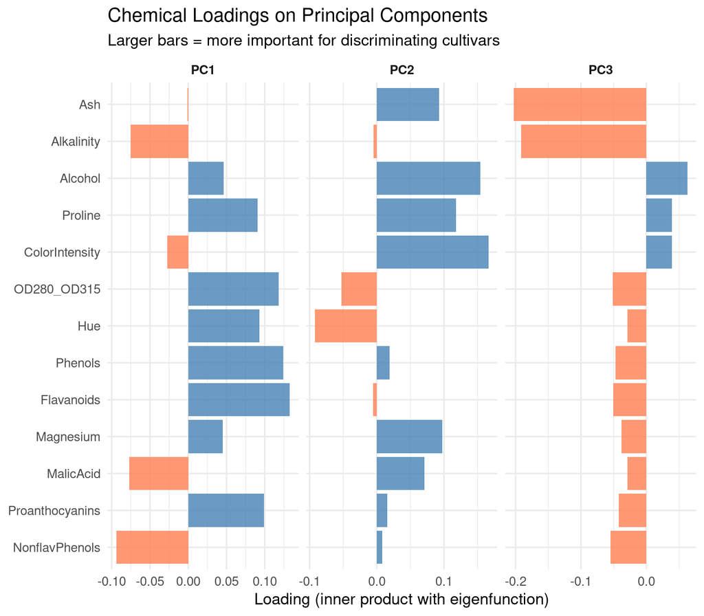

Variable importance per PC — the chemicals with largest loadings carry the most discriminating information.

```r
# Reconstruct the basis matrix used in andrews_transform
p <- ncol(X)
basis <- matrix(0, m, p)
basis[, 1] <- 1 / sqrt(2)
for (j in 2:p) {
  k <- ceiling((j - 1) / 2)
  if (j %% 2 == 0) {
    basis[, j] <- sin(k * t_grid)
  } else {
    basis[, j] <- cos(k * t_grid)
  }
}

# Project eigenfunctions onto basis: inner product (trapezoidal integration)
dt <- diff(t_grid[1:2])
chem_names <- colnames(wine)[-1]
loading_list <- list()

for (pc_idx in 1:3) {
  eigen_vals <- fpca$rotation$data[pc_idx, ]
  loadings <- as.numeric(t(basis) %*% eigen_vals) * dt
  loading_list[[pc_idx]] <- data.frame(
    Chemical = chem_names,
    Loading = loadings,
    AbsLoading = abs(loadings),
    PC = paste0("PC", pc_idx)
  )
}

df_loadings <- bind_rows(loading_list)

ggplot(df_loadings, aes(x = reorder(Chemical, AbsLoading), y = Loading,
                         fill = Loading > 0)) +
  geom_col(alpha = 0.8, show.legend = FALSE) +
  coord_flip() +
  facet_wrap(~ PC, scales = "free_x") +
  scale_fill_manual(values = c("TRUE" = "steelblue", "FALSE" = "coral")) +
  labs(title = "Chemical Loadings on Principal Components",
       subtitle = "Larger bars = more important for discriminating cultivars",
       x = NULL, y = "Loading (inner product with eigenfunction)") +
  theme(strip.text = element_text(face = "bold"))
```

The chemicals with the largest loadings on PC1 and PC2 carry the most discriminating information. For a cost-conscious lab, this is the difference between running 13 assays and running 5 without losing classification power.

### Comparison: Standard PCA on Raw Data

A natural question: why not just run `prcomp()` on the 13 × 178 matrix? Let’s do exactly that and compare.

```r
pca_raw <- prcomp(X, center = FALSE)  # already centered & scaled
var_raw <- pca_raw$sdev^2 / sum(pca_raw$sdev^2) * 100

cat("Variance explained — standard PCA vs FPCA:\n")
```

```
Variance explained — standard PCA vs FPCA:
```

```r
cat(sprintf("  %-6s %8s %8s\n", "PC", "Std PCA", "FPCA"))
```

```
  PC      Std PCA     FPCA
```

```r
for (i in 1:5) {
  cat(sprintf("  PC%-3d  %6.1f%%  %6.1f%%\n", i, var_raw[i], var_explained[i]))
}
```

```
  PC1      36.2%    45.0%
  PC2      19.2%    24.1%
  PC3      11.1%    13.9%
  PC4       7.1%     8.8%
  PC5       6.6%     8.2%
```

```r
# Scores are (nearly) identical
cat("Score correlations (|r|) between standard PCA and FPCA:\n")
```

```
Score correlations (|r|) between standard PCA and FPCA:
```

```r
for (i in 1:3) {
  r <- abs(cor(pca_raw$x[, i], fpca$x[, i]))
  cat(sprintf("  PC%d: |r| = %.4f\n", i, r))
}
```

```
  PC1: |r| = 1.0000
  PC2: |r| = 0.9998
  PC3: |r| = 0.9997
```

So again: why bother? Three reasons:

**1. Standard PCA gives you a loading *table*; FPCA gives you eigenfunction *curves*.** Here is what PC1 looks like in each framework:

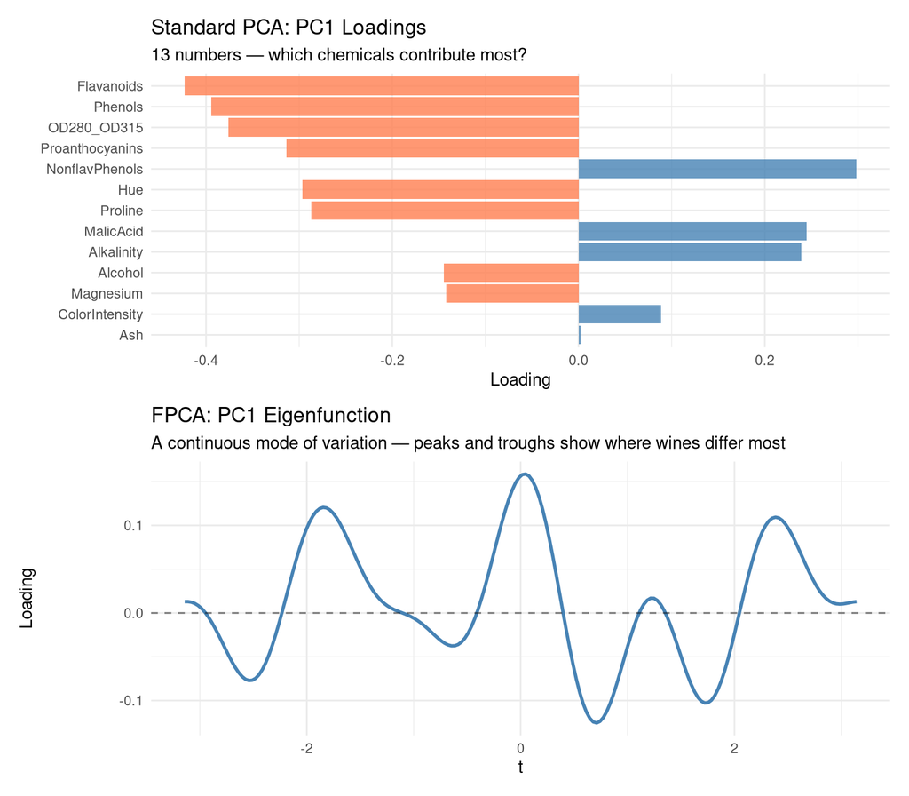

Standard PCA loadings (top) vs FPCA eigenfunction (bottom) — the same information, but the curve reveals the mode of variation as a visual shape.

```r
# Standard PCA loadings: a bar plot of 13 numbers
df_pca_loadings <- data.frame(
  Chemical = chem_names,
  Loading = pca_raw$rotation[, 1]
)

p_raw_loadings <- ggplot(df_pca_loadings,
                          aes(x = reorder(Chemical, abs(Loading)),
                              y = Loading, fill = Loading > 0)) +
  geom_col(alpha = 0.8, show.legend = FALSE) +
  coord_flip() +
  scale_fill_manual(values = c("TRUE" = "steelblue", "FALSE" = "coral")) +
  labs(title = "Standard PCA: PC1 Loadings",
       subtitle = "13 numbers — which chemicals contribute most?",
       x = NULL, y = "Loading") +
  theme_minimal()

# FPCA eigenfunction: a curve over [-π, π]
df_eigen <- data.frame(t = t_grid, loading = fpca$rotation$data[1, ])

p_eigen <- ggplot(df_eigen, aes(x = t, y = loading)) +
  geom_line(color = "steelblue", linewidth = 1) +
  geom_hline(yintercept = 0, linetype = "dashed", alpha = 0.5) +
  labs(title = "FPCA: PC1 Eigenfunction",
       subtitle = "A continuous mode of variation — peaks and troughs show where wines differ most",
       x = expression(t), y = "Loading") +
  theme_minimal()

p_raw_loadings / p_eigen
```

The bar plot tells you *which variables* load heavily on PC1. The eigenfunction tells you the same thing, but as a **continuous shape** — you can see the *mode of variation* as a visual signature. When the curve peaks, the corresponding Fourier frequencies (and therefore chemicals) are driving separation. When it crosses zero, those frequencies contribute nothing. For presentations and reports, the eigenfunction communicates the structure of variability far more intuitively than a table of 13 signed numbers.

**2. FPCA integrates naturally with the rest of the FDA toolkit.** Once you have Andrews curves, you can chain FPCA with depth, outlier detection, clustering, bootstrap CIs, and the functional boxplot — all operating in the same functional space, all using the same `fdata` object. Standard PCA is a standalone analysis step; FPCA is a module in a connected pipeline.

**3. The projection-back step gives you variable importance *in context*.** With standard PCA, you read variable loadings directly from the rotation matrix. With FPCA, you project eigenfunctions back onto the Fourier basis to recover variable importance — and those loadings are weighted by how each chemical contributes to the *curve’s shape*, not just to a linear combination. The results are consistent, but the FPCA framing connects variable importance to the visual output: the chemicals that shape the eigenfunction curves are the ones that shape the Andrews curves you’ve been looking at throughout this analysis.

**NoteHonest assessment**

If your only goal is “run PCA and get loadings,” standard `prcomp()` is simpler and gives you the same answer. The value of FPCA emerges when you’re already using Andrews curves for visualization, outlier detection, or clustering — then FPCA slots into the same pipeline rather than being a separate analysis track.

## Variable Ordering

Because the first Fourier terms carry the most visual weight, **placing important variables first** produces more informative plots. We rank the 13 chemicals by ANOVA F-statistic:

```r
f_stats <- sapply(1:ncol(X), function(j) {
  fit <- aov(X[, j] ~ cultivar)
  summary(fit)[[1]]$`F value`[1]
})
names(f_stats) <- chem_names
var_order <- order(f_stats, decreasing = TRUE)

cat("Variables ranked by ANOVA F-statistic:\n")
```

```
Variables ranked by ANOVA F-statistic:
```

```r
for (i in var_order) {
  cat(sprintf("  %s: F = %.1f\n", names(f_stats)[i], f_stats[i]))
}
```

```
  Flavanoids: F = 233.9
  Proline: F = 207.9
  OD280_OD315: F = 190.0
  Alcohol: F = 135.1
  ColorIntensity: F = 120.7
  Hue: F = 101.3
  Phenols: F = 93.7
  MalicAcid: F = 36.9
  Alkalinity: F = 35.8
  Proanthocyanins: F = 30.3
  NonflavPhenols: F = 27.6
  Ash: F = 13.3
  Magnesium: F = 12.4
```

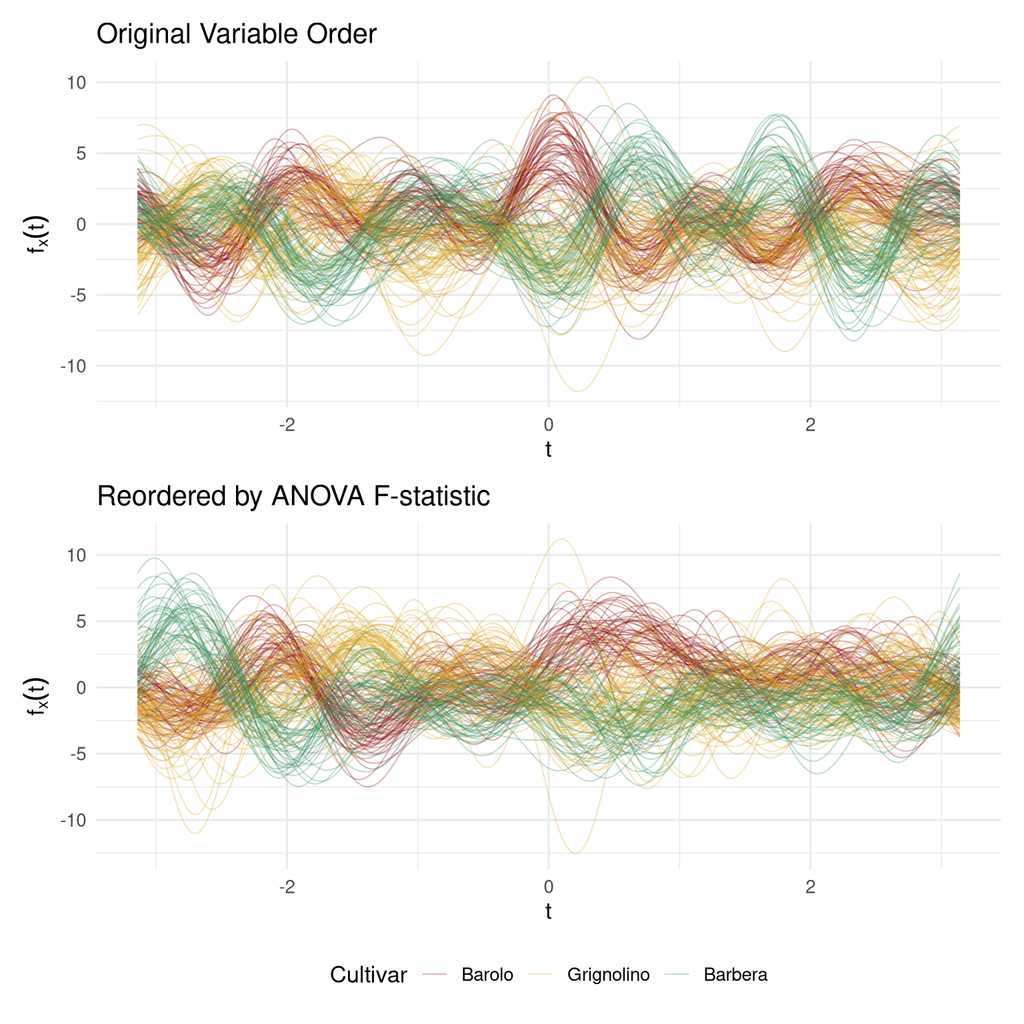

Variable ordering affects visual clarity but not analytical results — distance preservation holds regardless.

```r
fd_original <- andrews_transform(X)
fd_reordered <- andrews_transform(X[, var_order])

# Helper to make curve data frame
make_curve_df <- function(fd, label) {
  data.frame(
    t = rep(t_grid, n),
    value = as.vector(t(fd$data)),
    curve = rep(1:n, each = m),
    Cultivar = rep(cultivar, each = m),
    Ordering = label
  )
}

p_orig <- ggplot(make_curve_df(fd_original, "Original"),
                 aes(x = t, y = value, group = curve, color = Cultivar)) +
  geom_line(alpha = 0.3, linewidth = 0.35) +
  scale_color_manual(values = c("Barolo" = "#8B0000", "Grignolino" = "#DAA520",
                                 "Barbera" = "#2E8B57")) +
  labs(title = "Original Variable Order", x = expression(t), y = expression(f[x](t))) +
  theme(legend.position = "none")

p_reord <- ggplot(make_curve_df(fd_reordered, "Reordered"),
                  aes(x = t, y = value, group = curve, color = Cultivar)) +
  geom_line(alpha = 0.3, linewidth = 0.35) +
  scale_color_manual(values = c("Barolo" = "#8B0000", "Grignolino" = "#DAA520",
                                 "Barbera" = "#2E8B57")) +
  labs(title = "Reordered by ANOVA F-statistic", x = expression(t), y = expression(f[x](t))) +
  theme(legend.position = "bottom")

p_orig / p_reord
```

The reordered plot shows clearer cultivar separation because the most discriminating chemicals now drive the dominant low-frequency Fourier terms. Crucially, clustering results are **identical** regardless of ordering — this is a presentation improvement, not a data manipulation.

## The Functional Boxplot: A Cultivar Specification

Classical boxplots summarize one variable at a time. If you want to monitor 13 chemicals, you need 13 boxplots, and there’s no way to assess whether the *combination* of values is normal. The functional boxplot solves this: it defines a simultaneous envelope over all 13 chemicals (encoded in the curve), giving you a single visual that says “this is what a normal wine looks like.”

### Overall Functional Boxplot

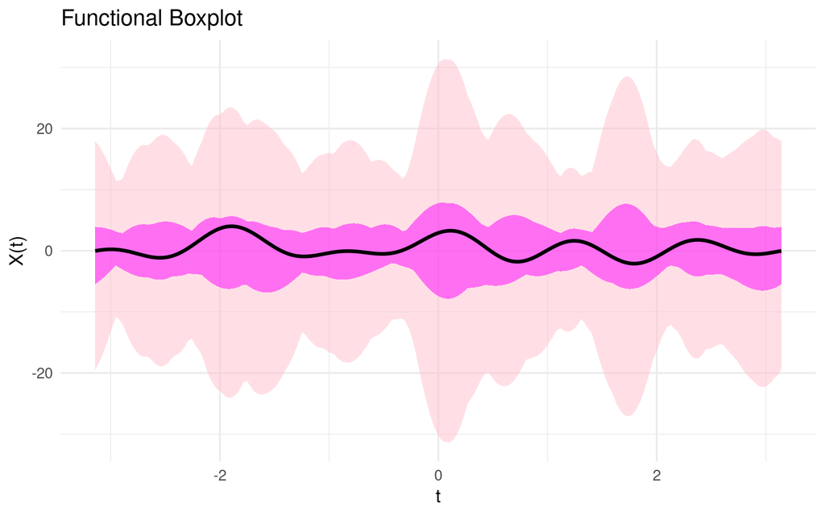

```r
fbp <- boxplot(fd_wine)
fbp$plot
```

The median curve (black) is the **most typical wine** — the one with the highest functional depth. The magenta band is the **50% central region**: half of all wines fall within this envelope at every point. The pink band extends to the fences (1.5× the envelope width); any wine whose curve escapes the pink band at *any* Fourier frequency is automatically flagged.

### Per-Cultivar Specifications

The overall boxplot mixes all three cultivars. For quality control, what you really want is a **cultivar-specific specification** — what should a typical Barolo, Grignolino, or Barbera look like?

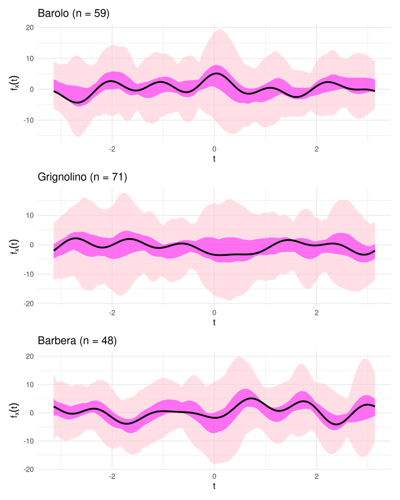

Per-cultivar functional boxplots — each cultivar gets its own ‘normal range’ specification.

```r
bp_list <- list()
for (cv in levels(cultivar)) {
  idx <- which(cultivar == cv)
  fd_cv <- fd_wine[idx]
  fbp_cv <- boxplot(fd_cv)

  bp_list[[cv]] <- fbp_cv$plot +
    labs(title = sprintf("%s (n = %d)", cv, length(idx)),
         x = expression(t), y = expression(f[x](t)))
}

bp_list[["Barolo"]] / bp_list[["Grignolino"]] / bp_list[["Barbera"]]
```

These three boxplots define a **visual specification** for each cultivar. A quality controller can now take a new wine, compute its Andrews curve, and overlay it on the appropriate cultivar’s boxplot. If the curve falls within the magenta band, the wine is typical. If it escapes the pink fences, investigate.

### Incoming Batch Monitoring

Let’s simulate this workflow. We take Wine 122 (the suspect Grignolino from our outlier analysis) and Wine 107 (the most typical Grignolino by depth) and check them against the Grignolino specification:

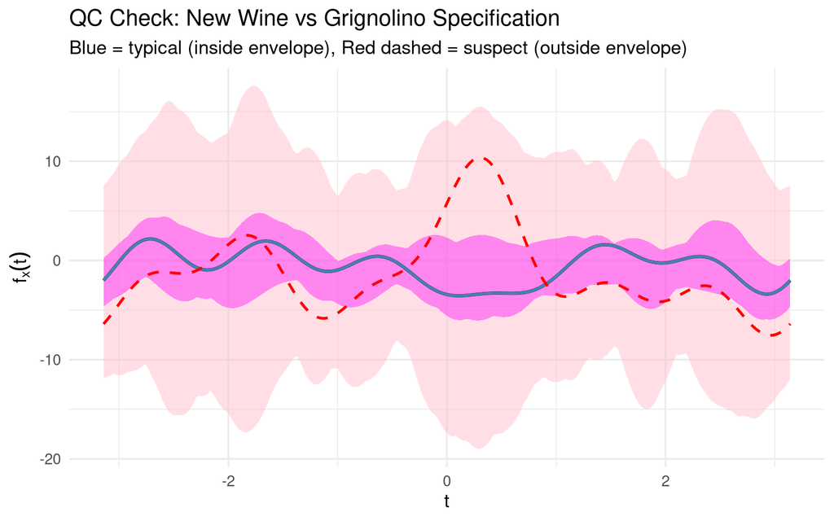

Incoming batch check — Wine 107 (blue) sits inside the central region; Wine 122 (red dashed) escapes it, confirming it doesn’t match the Grignolino specification.

```r
grig_idx <- which(cultivar == "Grignolino")
fd_grig <- fd_wine[grig_idx]
fbp_grig <- boxplot(fd_grig)

# Extract envelope and fence for custom overlay
df_envelope <- data.frame(
  t = t_grid,
  env_min = fbp_grig$envelope$min, env_max = fbp_grig$envelope$max,
  fence_min = fbp_grig$fence$min, fence_max = fbp_grig$fence$max,
  median_val = fd_grig$data[fbp_grig$median, ]
)

# Wine 122 and Wine 107 curves
df_check <- rbind(
  data.frame(t = t_grid, value = fd_wine$data[122, ], Wine = "Wine 122 (suspect)"),
  data.frame(t = t_grid, value = fd_wine$data[107, ], Wine = "Wine 107 (typical)")
)

ggplot() +
  geom_ribbon(data = df_envelope, aes(x = t, ymin = fence_min, ymax = fence_max),
              fill = "pink", alpha = 0.5) +
  geom_ribbon(data = df_envelope, aes(x = t, ymin = env_min, ymax = env_max),
              fill = "magenta", alpha = 0.4) +
  geom_line(data = df_envelope, aes(x = t, y = median_val),
            color = "black", linewidth = 1) +
  geom_line(data = filter(df_check, Wine == "Wine 107 (typical)"),
            aes(x = t, y = value), color = "steelblue", linewidth = 0.9) +
  geom_line(data = filter(df_check, Wine == "Wine 122 (suspect)"),
            aes(x = t, y = value), color = "red", linewidth = 0.9,
            linetype = "dashed") +
  labs(title = "QC Check: New Wine vs Grignolino Specification",
       subtitle = "Blue = typical (inside envelope), Red dashed = suspect (outside envelope)",
       x = expression(t), y = expression(f[x](t)))
```

No 13-column spreadsheet comparison needed. One glance tells the story: Wine 107 traces the median closely; Wine 122’s curve departs from the envelope in several regions, particularly around $t \approx 0$ where the $\sin(t)$ and $\cos(t)$ terms (encoding Malic Acid and Ash) dominate. This is a **multivariate control chart** — monitoring all 13 chemicals simultaneously in a single visual.

There is no simple classical equivalent. A 13-dimensional confidence ellipsoid exists mathematically, but you can’t plot it, you can’t show it to a plant manager, and you can’t point to the region where the wine deviates. The functional boxplot does all three.

## Depth as a Typicality Score

Functional depth gives every wine a scalar **typicality score** within its cultivar. This is a concept with no clean classical equivalent — it simultaneously accounts for all 13 chemicals without requiring a parametric model or covariance matrix inversion.

```r
# Compute within-cultivar depth rankings
depth_rankings <- lapply(levels(cultivar), function(cv) {
  idx <- which(cultivar == cv)
  fd_cv <- fd_wine[idx]
  depths <- depth.MBD(fd_cv)
  data.frame(
    Wine = idx,
    Cultivar = cv,
    Depth = round(depths, 4),
    Rank = rank(-depths)
  )
})
df_depths <- bind_rows(depth_rankings)

# Show top 3 and bottom 3 per cultivar
top_bottom <- df_depths |>
  group_by(Cultivar) |>
  arrange(Rank) |>
  slice(c(1:3, (n()-2):n())) |>
  mutate(Status = ifelse(Rank <= 3, "Most typical", "Least typical"))

kable(top_bottom |> select(Cultivar, Wine, Depth, Rank, Status),
      caption = "Most and least typical wines per cultivar (by functional depth)")
```

Most and least typical wines per cultivar (by functional depth)

| Cultivar | Wine | Depth | Rank | Status |
| --- | --- | --- | --- | --- |
| Barbera | 175 | 0.4756 | 1 | Most typical |
| Barbera | 149 | 0.4734 | 2 | Most typical |
| Barbera | 164 | 0.4311 | 3 | Most typical |
| Barbera | 153 | 0.2874 | 46 | Least typical |
| Barbera | 160 | 0.2434 | 47 | Least typical |
| Barbera | 159 | 0.1980 | 48 | Least typical |
| Barolo | 58 | 0.4351 | 1 | Most typical |
| Barolo | 49 | 0.4321 | 2 | Most typical |
| Barolo | 36 | 0.4084 | 3 | Most typical |
| Barolo | 40 | 0.2640 | 57 | Least typical |
| Barolo | 15 | 0.2370 | 58 | Least typical |
| Barolo | 26 | 0.1994 | 59 | Least typical |
| Grignolino | 107 | 0.4394 | 1 | Most typical |
| Grignolino | 82 | 0.4377 | 2 | Most typical |
| Grignolino | 118 | 0.4360 | 3 | Most typical |
| Grignolino | 70 | 0.2244 | 69 | Least typical |
| Grignolino | 96 | 0.2086 | 70 | Least typical |
| Grignolino | 122 | 0.1938 | 71 | Least typical |

The “most typical” wines are the ones a sommelier would call textbook examples of their cultivar. The “least typical” wines — 122, 96, 70 for Grignolino; 159 for Barbera — are exactly the ones our outlier analysis flagged. Depth provides a continuous ranking, not a binary flag, so the quality controller can set their own threshold: investigate the bottom 5%? The bottom 10%?

### Robust Location: Trimmed Mean vs Ordinary Mean

Depth also enables **robust estimation**. The trimmed mean discards the shallowest curves (the most atypical wines) before averaging, giving a center estimate that resists contamination:

```r
fd_grig <- fd_wine[which(cultivar == "Grignolino")]

# Full sample estimates
fn_mean_full <- mean(fd_grig)
fn_trimmed_full <- trimmed(fd_grig, trim = 0.25)

# Remove 3 most extreme outliers and recompute
grig_clean <- setdiff(which(cultivar == "Grignolino"), c(70, 96, 122))
fd_grig_clean <- fd_wine[grig_clean]
fn_mean_clean <- mean(fd_grig_clean)
fn_trimmed_clean <- trimmed(fd_grig_clean, trim = 0.25)

# Measure how much each shifted
mean_shift <- sqrt(sum((fn_mean_full$data - fn_mean_clean$data)^2) *
                   diff(t_grid[1:2]))
trimmed_shift <- sqrt(sum((fn_trimmed_full$data - fn_trimmed_clean$data)^2) *
                      diff(t_grid[1:2]))

cat(sprintf("Removing 3 extreme Grignolino outliers (wines 70, 96, 122):\n"))
```

```
Removing 3 extreme Grignolino outliers (wines 70, 96, 122):
```

```r
cat(sprintf("  Mean curve shifted by:          %.2f\n", mean_shift))
```

```
  Mean curve shifted by:          0.32
```

```r
cat(sprintf("  25%% trimmed mean shifted by:    %.2f\n", trimmed_shift))
```

```
  25% trimmed mean shifted by:    0.22
```

```r
cat(sprintf("  Trimmed mean is %.0f%% more stable\n",
            100 * (mean_shift - trimmed_shift) / mean_shift))
```

```
  Trimmed mean is 33% more stable
```

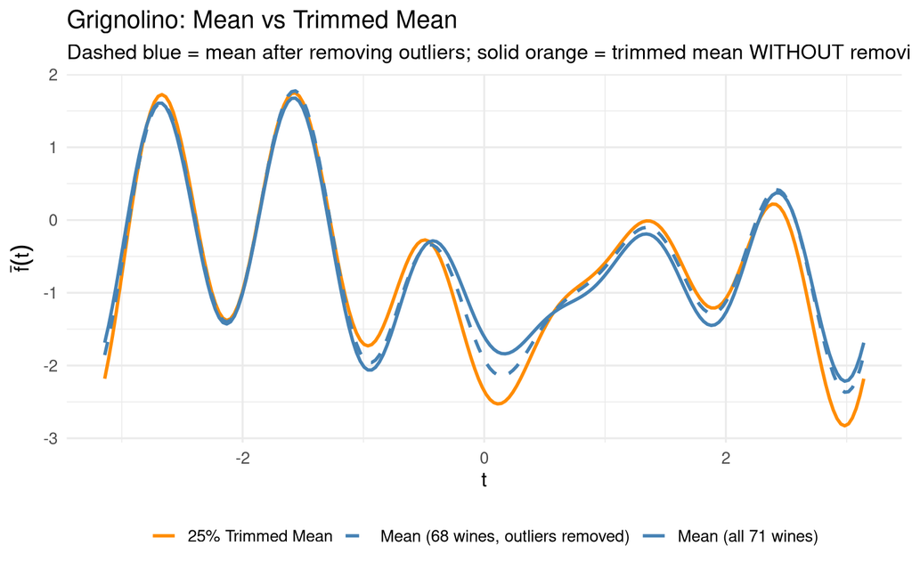

The 25% trimmed mean (orange) is more stable than the ordinary mean (blue) when outliers are present.

```r
df_robust <- rbind(
  data.frame(t = t_grid, value = as.numeric(fn_mean_full$data),
             Estimator = "Mean (all 71 wines)"),
  data.frame(t = t_grid, value = as.numeric(fn_trimmed_full$data),
             Estimator = "25% Trimmed Mean"),
  data.frame(t = t_grid, value = as.numeric(fn_mean_clean$data),
             Estimator = "Mean (68 wines, outliers removed)")
)

ggplot(df_robust, aes(x = t, y = value, color = Estimator, linetype = Estimator)) +
  geom_line(linewidth = 1) +
  scale_color_manual(values = c("Mean (all 71 wines)" = "steelblue",
                                 "25% Trimmed Mean" = "darkorange",
                                 "Mean (68 wines, outliers removed)" = "steelblue")) +
  scale_linetype_manual(values = c("Mean (all 71 wines)" = "solid",
                                    "25% Trimmed Mean" = "solid",
                                    "Mean (68 wines, outliers removed)" = "dashed")) +
  labs(title = "Grignolino: Mean vs Trimmed Mean",
       subtitle = "Dashed blue = mean after removing outliers; solid orange = trimmed mean WITHOUT removing them",
       x = expression(t), y = expression(bar(f)(t))) +
  theme(legend.position = "bottom",
        legend.title = element_blank())
```

## From Validation to Monitoring

So far, this article has been a retrospective analysis: we took 178 wines, found outliers, verified clusters, identified important chemicals. But a quality lab doesn’t analyze the same 178 wines forever. New batches arrive every week. The real question is: **can we turn this analysis into an ongoing monitoring system?**

The answer is yes, and the functional framework makes it natural. The workflow has three phases.

### Phase 1: Establish the Reference (Process Validation)

During process validation, you collect a representative set of wines for each cultivar and compute the **reference profile**: the trimmed mean curve and an envelope that captures the expected range of normal variation.

We use the bootstrap to construct two types of bands:

- A **confidence band** (blue) for the trimmed mean — this quantifies uncertainty about the cultivar’s *average* profile (“where is the center?”).
- A **prediction band** (gray) for individual wines — this captures the range where a *single new observation* is expected to fall (“is this wine normal?”).

Both are **prediction intervals**: they use the observed sample to predict where future observations or statistics will land. This is the appropriate tool for *routine monitoring*, where you ask “does this new wine look like my reference set?”

For *process transfer* — validating that a new vineyard, lab, or fermentation facility produces equivalent wines — the statistically correct tool is a **tolerance interval**. A tolerance interval guarantees that *at least a specified proportion* of the population (e.g., 95%) falls within the band, with a given confidence level (e.g., 99%). This dual coverage is stricter than a prediction interval, which only covers the *next single observation*. Computing functional tolerance intervals requires adjustments for simultaneous coverage across the entire curve domain, which goes beyond what we demonstrate here, but the conceptual framework is the same: replace the bootstrap quantiles below with the appropriate tolerance factors (e.g., based on non-central $\chi^2$ or Bonferroni-corrected normal order statistics). For the purposes of this article, we proceed with prediction bands as a practical approximation:

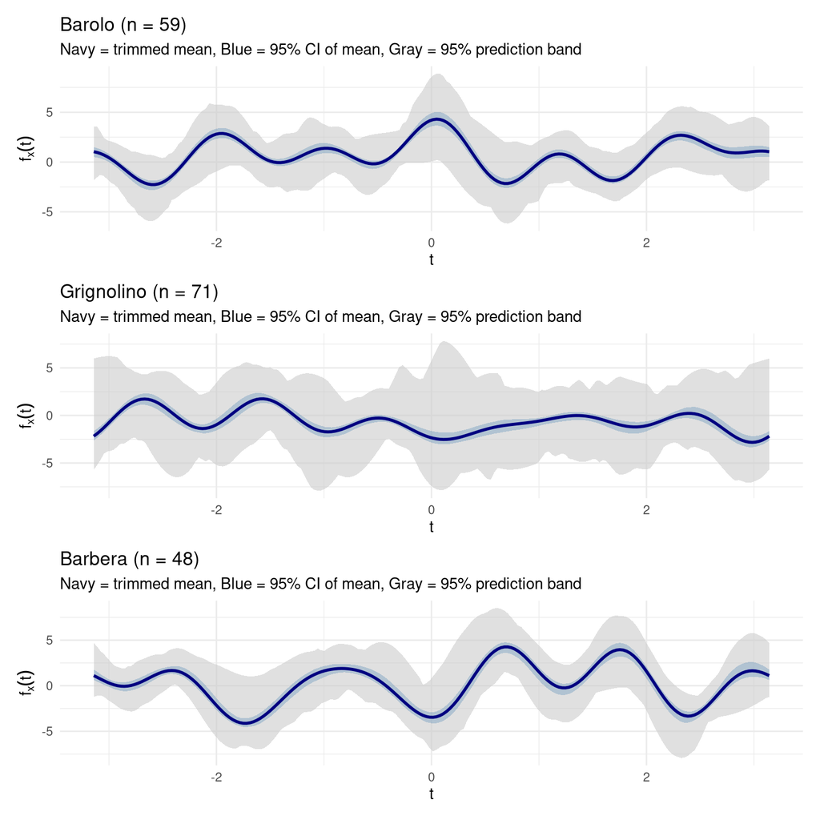

```r
tolerance_plots <- list()

for (cv in levels(cultivar)) {
  idx <- which(cultivar == cv)
  fd_cv <- fd_wine[idx]

  # Bootstrap the trimmed mean to get a tolerance band
  # Using the percentile method on pointwise quantiles of bootstrap curves
  n_boot <- 500
  boot_obj <- fdata.bootstrap(fd_cv, n.boot = n_boot, method = "naive",
                               seed = 42)

  # For each bootstrap sample, compute the trimmed mean
  boot_means <- matrix(NA, n_boot, m)
  for (b in seq_len(n_boot)) {
    boot_means[b, ] <- as.numeric(trimmed(boot_obj$boot.samples[[b]],
                                           trim = 0.25)$data)
  }

  # Pointwise 2.5% and 97.5% quantiles of bootstrap trimmed means
  band_lower <- apply(boot_means, 2, quantile, probs = 0.025)
  band_upper <- apply(boot_means, 2, quantile, probs = 0.975)

  # Also compute a wider prediction band using the raw bootstrap curves
  # This captures individual wine variability, not just mean uncertainty
  boot_curves <- matrix(NA, n_boot, m)
  for (b in seq_len(n_boot)) {
    # Pick a random curve from each bootstrap sample
    boot_curves[b, ] <- boot_obj$boot.samples[[b]]$data[
      sample(nrow(boot_obj$boot.samples[[b]]$data), 1), ]
  }
  pred_lower <- apply(boot_curves, 2, quantile, probs = 0.025)
  pred_upper <- apply(boot_curves, 2, quantile, probs = 0.975)

  ref_mean <- as.numeric(trimmed(fd_cv, trim = 0.25)$data)

  df_band <- data.frame(
    t = t_grid,
    mean = ref_mean,
    ci_lower = band_lower, ci_upper = band_upper,
    pred_lower = pred_lower, pred_upper = pred_upper
  )

  tolerance_plots[[cv]] <- ggplot(df_band, aes(x = t)) +
    geom_ribbon(aes(ymin = pred_lower, ymax = pred_upper),
                fill = "gray80", alpha = 0.6) +
    geom_ribbon(aes(ymin = ci_lower, ymax = ci_upper),
                fill = "steelblue", alpha = 0.3) +
    geom_line(aes(y = mean), color = "navy", linewidth = 1) +
    labs(title = sprintf("%s (n = %d)", cv, length(idx)),
         subtitle = "Navy = trimmed mean, Blue = 95% CI of mean, Gray = 95% prediction band",
         x = expression(t), y = expression(f[x](t))) +
    theme_minimal()
}

tolerance_plots[["Barolo"]] / tolerance_plots[["Grignolino"]] / tolerance_plots[["Barbera"]]
```

The **blue band** (confidence band for the mean) answers: “where does the cultivar’s average profile sit?” The **gray band** (prediction band for individual wines) answers: “where can a single new wine’s curve fall and still be considered normal?” For routine QC, the gray prediction band is the operational acceptance criterion: any new wine whose Andrews curve stays entirely inside it passes.

For formal process transfer validation, you would replace the gray band with a proper tolerance band (wider, to guarantee population coverage with confidence). The prediction band shown here is a pragmatic starting point that works well for ongoing monitoring.

### Phase 2: Process Transfer

When a process is transferred — to a new vineyard, a new fermentation facility, or a new analytical lab — you need to verify that the new process produces wines within the validated specification. Ideally this would use tolerance bands (guaranteeing population coverage); here we demonstrate the workflow with prediction bands as a practical approximation.

The key advantage of the functional approach is that when a wine *fails*, you can trace back to **which chemicals** caused the deviation. Because the Andrews curve maps each Fourier frequency to specific input variables, a violation at a particular region of the curve implicates specific chemicals. We can also directly compare the original (standardized) chemical values to pinpoint exactly where the new wine deviates:

```r
# Simulate: take a Barolo wine and check against the Barolo tolerance band
barolo_idx <- which(cultivar == "Barolo")
fd_barolo <- fd_wine[barolo_idx]

# Compute the prediction band for Barolo
boot_barolo <- fdata.bootstrap(fd_barolo, n.boot = 500, method = "naive",
                                seed = 42)
boot_barolo_curves <- matrix(NA, 500, m)
for (b in 1:500) {
  boot_barolo_curves[b, ] <- boot_barolo$boot.samples[[b]]$data[
    sample(nrow(boot_barolo$boot.samples[[b]]$data), 1), ]
}
barolo_pred_lower <- apply(boot_barolo_curves, 2, quantile, probs = 0.025)
barolo_pred_upper <- apply(boot_barolo_curves, 2, quantile, probs = 0.975)
barolo_mean <- as.numeric(trimmed(fd_barolo, trim = 0.25)$data)

df_barolo_band <- data.frame(
  t = t_grid,
  mean = barolo_mean,
  pred_lower = barolo_pred_lower,
  pred_upper = barolo_pred_upper
)

# Test wines: a true Barolo (wine 36, typical) and a Grignolino (wine 107)
df_test_wines <- rbind(
  data.frame(t = t_grid, value = fd_wine$data[36, ],
             Wine = "Wine 36 (Barolo — typical)"),
  data.frame(t = t_grid, value = fd_wine$data[107, ],
             Wine = "Wine 107 (Grignolino)")
)

# Check which wines stay inside the band
for (w in c(36, 107)) {
  inside <- all(fd_wine$data[w, ] >= barolo_pred_lower &
                fd_wine$data[w, ] <= barolo_pred_upper)
  cat(sprintf("Wine %d (%s): %s Barolo prediction band\n",
              w, cultivar[w], ifelse(inside, "INSIDE", "OUTSIDE")))
}
```

```
Wine 36 (Barolo): INSIDE Barolo prediction band
Wine 107 (Grignolino): OUTSIDE Barolo prediction band
```

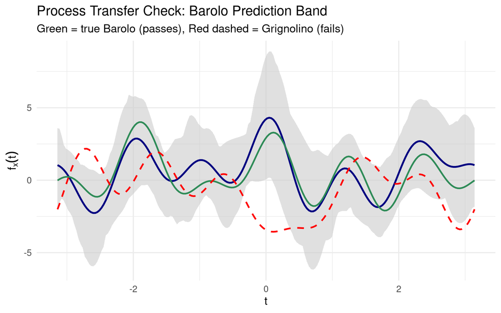

Process transfer check — does a new wine from a different source match the Barolo specification?

```r
ggplot() +
  geom_ribbon(data = df_barolo_band,
              aes(x = t, ymin = pred_lower, ymax = pred_upper),
              fill = "gray80", alpha = 0.6) +
  geom_line(data = df_barolo_band, aes(x = t, y = mean),
            color = "navy", linewidth = 1) +
  geom_line(data = filter(df_test_wines, Wine == "Wine 36 (Barolo — typical)"),
            aes(x = t, y = value), color = "#2E8B57", linewidth = 0.9) +
  geom_line(data = filter(df_test_wines, Wine == "Wine 107 (Grignolino)"),
            aes(x = t, y = value), color = "red", linewidth = 0.9,
            linetype = "dashed") +
  labs(title = "Process Transfer Check: Barolo Prediction Band",
       subtitle = "Green = true Barolo (passes), Red dashed = Grignolino (fails)",
       x = expression(t), y = expression(f[x](t)))
```

A true Barolo stays inside the gray band; a Grignolino immediately violates it. But the critical follow-up question is: **which chemicals caused the failure?** Because we preserved the mapping between curve and original variables, we can answer this directly:

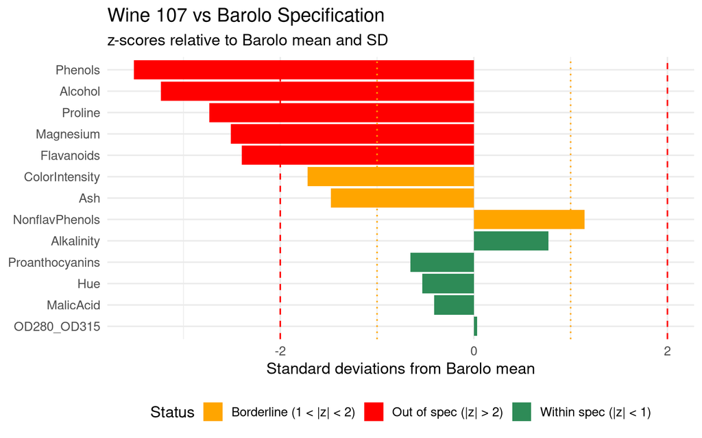

Chemical-level diagnostic: which measurements caused Wine 107 to fail the Barolo specification?

```r
# Compare wine 107 (Grignolino) against Barolo reference ranges
barolo_means <- colMeans(X[barolo_idx, ])
barolo_sds <- apply(X[barolo_idx, ], 2, sd)

wine107_z <- (X[107, ] - barolo_means) / barolo_sds

df_diag <- data.frame(
  Chemical = chem_names,
  z_score = as.numeric(wine107_z)
) |>
  dplyr::mutate(
    Status = dplyr::case_when(
      abs(z_score) > 2 ~ "Out of spec (|z| > 2)",
      abs(z_score) > 1 ~ "Borderline (1 < |z| < 2)",
      TRUE ~ "Within spec (|z| < 1)"
    ),
    Chemical = factor(Chemical, levels = Chemical[order(abs(z_score))])
  )

ggplot(df_diag, aes(x = Chemical, y = z_score, fill = Status)) +
  geom_col() +
  geom_hline(yintercept = c(-2, 2), linetype = "dashed", color = "red") +
  geom_hline(yintercept = c(-1, 1), linetype = "dotted", color = "orange") +
  coord_flip() +
  scale_fill_manual(values = c("Out of spec (|z| > 2)" = "red",
                                "Borderline (1 < |z| < 2)" = "orange",
                                "Within spec (|z| < 1)" = "#2E8B57")) +
  labs(title = "Wine 107 vs Barolo Specification",
       subtitle = "z-scores relative to Barolo mean and SD",
       x = NULL, y = "Standard deviations from Barolo mean") +
  theme(legend.position = "bottom")
```

```r
# Report the failing chemicals
failing <- df_diag |> dplyr::filter(abs(z_score) > 2) |>
  dplyr::arrange(dplyr::desc(abs(z_score)))
cat("Chemicals out of spec (|z| > 2):\n")
```

```
Chemicals out of spec (|z| > 2):
```

```r
for (i in seq_len(nrow(failing))) {
  cat(sprintf("  %s: z = %+.1f (%s Barolo range)\n",
              failing$Chemical[i], failing$z_score[i],
              ifelse(failing$z_score[i] > 0, "above", "below")))
}
```

```
  Phenols: z = -3.5 (below Barolo range)
  Alcohol: z = -3.2 (below Barolo range)
  Proline: z = -2.7 (below Barolo range)
  Magnesium: z = -2.5 (below Barolo range)
  Flavanoids: z = -2.4 (below Barolo range)
```

### Phase 3: Ongoing Process Monitoring

Once the process is validated, monitoring becomes routine. Each new batch is:

1. Measured for the 13 chemicals (or the reduced set identified by FPCA)
2. Transformed into an Andrews curve
3. Checked against the cultivar-specific tolerance band *and* the functional boxplot fences

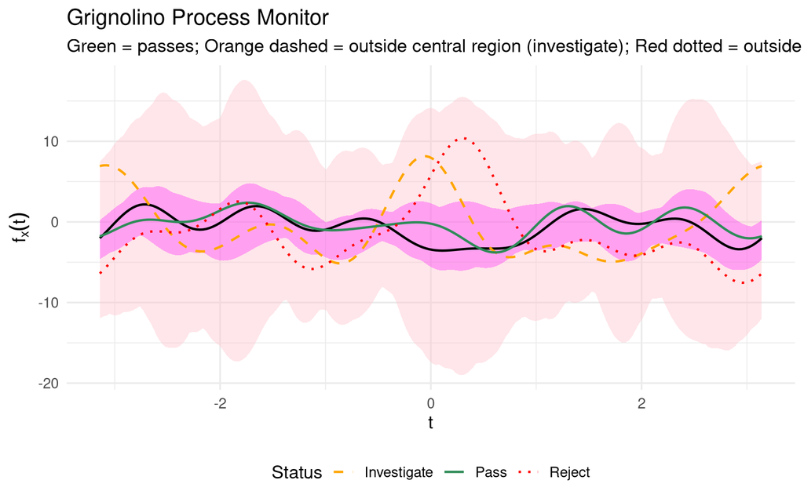

```r
# Build the monitoring view: functional boxplot + incoming wines
grig_idx <- which(cultivar == "Grignolino")
fd_grig <- fd_wine[grig_idx]
fbp_grig <- boxplot(fd_grig)

df_monitor <- data.frame(
  t = t_grid,
  env_min = fbp_grig$envelope$min, env_max = fbp_grig$envelope$max,
  fence_min = fbp_grig$fence$min, fence_max = fbp_grig$fence$max,
  median_val = fd_grig$data[fbp_grig$median, ]
)

# "Incoming" wines: one normal, one outlier, one mislabeled
incoming <- rbind(
  data.frame(t = t_grid, value = fd_wine$data[82, ],
             Wine = "Batch A (normal)", Status = "Pass"),
  data.frame(t = t_grid, value = fd_wine$data[96, ],
             Wine = "Batch B (Mg outlier)", Status = "Investigate"),
  data.frame(t = t_grid, value = fd_wine$data[122, ],
             Wine = "Batch C (mislabel?)", Status = "Reject")
)

ggplot() +
  geom_ribbon(data = df_monitor, aes(x = t, ymin = fence_min, ymax = fence_max),
              fill = "pink", alpha = 0.4) +
  geom_ribbon(data = df_monitor, aes(x = t, ymin = env_min, ymax = env_max),
              fill = "magenta", alpha = 0.3) +
  geom_line(data = df_monitor, aes(x = t, y = median_val),
            color = "black", linewidth = 0.8) +
  geom_line(data = incoming,
            aes(x = t, y = value, color = Status, linetype = Status),
            linewidth = 0.8) +
  scale_color_manual(values = c("Pass" = "#2E8B57", "Investigate" = "orange",
                                 "Reject" = "red")) +
  scale_linetype_manual(values = c("Pass" = "solid", "Investigate" = "dashed",
                                    "Reject" = "dotted")) +
  labs(title = "Grignolino Process Monitor",
       subtitle = "Green = passes; Orange dashed = outside central region (investigate); Red dotted = outside envelope (reject)",
       x = expression(t), y = expression(f[x](t))) +
  theme(legend.position = "bottom")
```

Again, the crucial advantage is that a monitoring alert doesn’t end with “investigate” — it tells you **which chemicals** are driving the deviation. For each flagged batch, we can decompose the alert back into the original measurement space:

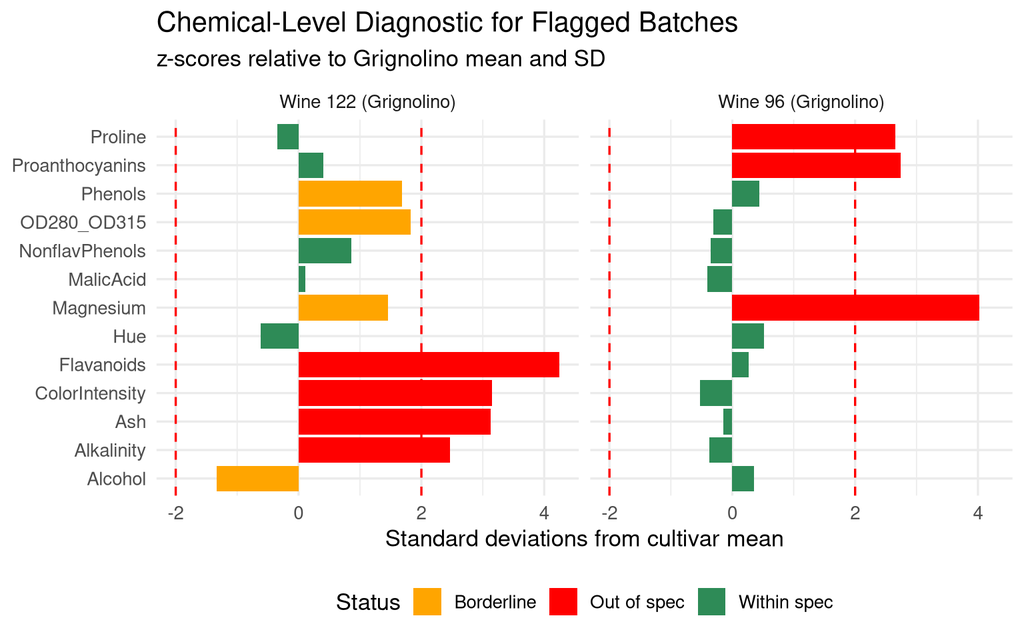

Monitoring diagnostic: which chemicals drive each alert?

```r
# For the flagged wines (96 = investigate, 122 = reject), compute z-scores
# relative to Grignolino reference
grig_means <- colMeans(X[grig_idx, ])
grig_sds <- apply(X[grig_idx, ], 2, sd)

diag_list <- list()
for (w in c(96, 122)) {
  wz <- (X[w, ] - grig_means) / grig_sds
  diag_list[[as.character(w)]] <- data.frame(
    Chemical = chem_names,
    z_score = as.numeric(wz),
    Wine = sprintf("Wine %d (%s)", w, cultivar[w])
  )
}

df_mon_diag <- do.call(rbind, diag_list) |>
  dplyr::mutate(
    Status = dplyr::case_when(
      abs(z_score) > 2 ~ "Out of spec",
      abs(z_score) > 1 ~ "Borderline",
      TRUE ~ "Within spec"
    )
  )

ggplot(df_mon_diag, aes(x = Chemical, y = z_score, fill = Status)) +
  geom_col() +
  geom_hline(yintercept = c(-2, 2), linetype = "dashed", color = "red") +
  coord_flip() +
  scale_fill_manual(values = c("Out of spec" = "red",
                                "Borderline" = "orange",
                                "Within spec" = "#2E8B57")) +
  facet_wrap(~ Wine) +
  labs(title = "Chemical-Level Diagnostic for Flagged Batches",
       subtitle = "z-scores relative to Grignolino mean and SD",
       x = NULL, y = "Standard deviations from cultivar mean") +
  theme(legend.position = "bottom")
```

Wine 96 (the “Investigate” batch) has a small number of chemicals pulling it outside the central region — the alert is localized, and the quality team knows exactly which assays to re-run. Wine 122 (the “Reject” batch) deviates on a broad set of chemicals in a pattern consistent with a different cultivar entirely — confirming the mislabeling hypothesis from the outlier analysis.

This is the operational payoff of the entire pipeline. The validation phase (sections 2–8 of this article) produces the reference profiles, prediction bands, and decision rules. The monitoring phase applies them to every new batch with a single curve overlay *plus* a chemical-level breakdown when something goes wrong. The quality controller doesn’t need to understand Fourier analysis or functional depth — they see a curve, a band, a red/yellow/green signal, and a bar chart telling them which chemicals to investigate.

For regulated industries, this workflow maps directly to the **process validation lifecycle** (ICH Q8-Q12, FDA guidance):

- **Stage 1 (Process Design)**: FPCA identifies critical quality attributes (which chemicals matter); clustering validates groupings
- **Stage 2 (Process Qualification)**: prediction bands define acceptance criteria (tolerance bands for formal validation); the permutation test provides statistical evidence of cultivar distinctness
- **Stage 3 (Continued Process Verification)**: the functional boxplot serves as the ongoing control chart; depth ranking flags drifting batches before they exceed limits; chemical-level diagnostics pinpoint root causes

## So Why Not Just Use Standard Statistics?

Throughout this article, we’ve compared FDA methods against their classical counterparts. Let’s be honest about what we found:

```r
comp_df <- data.frame(
  Task = c("Outlier detection", "Clustering", "PCA / FPCA",
           "Quality monitoring", "Hypothesis testing", "Robust estimation"),
  `Classical Method` = c(
    "Mahalanobis distance",
    "k-means on raw data",
    "prcomp() on raw matrix",
    "Per-variable control charts (13 separate charts)",
    "MANOVA (assumes multivariate normality)",
    "Trimmed column means (per variable)"
  ),
  `What FDA Adds` = c(
    "Three methods classifying the TYPE of outlier (magnitude vs shape vs rank); visual curve diagnostics",
    "Cluster centers as curves; fuzzy membership; visual overlay",
    "Eigenfunction curves showing modes of variation; pipeline integration",
    "Functional boxplot: one chart monitoring all 13 chemicals simultaneously",
    "Nonparametric permutation test; bootstrap CIs showing WHERE profiles diverge",
    "Depth-based trimmed mean: robust center that respects multivariate structure"
  ),
  check.names = FALSE
)
kable(comp_df, caption = "Classical vs FDA: what each approach delivers")
```

Classical vs FDA: what each approach delivers

| Task | Classical Method | What FDA Adds |
| --- | --- | --- |
| Outlier detection | Mahalanobis distance | Three methods classifying the TYPE of outlier (magnitude vs shape vs rank); visual curve diagnostics |
| Clustering | k-means on raw data | Cluster centers as curves; fuzzy membership; visual overlay |
| PCA / FPCA | prcomp() on raw matrix | Eigenfunction curves showing modes of variation; pipeline integration |
| Quality monitoring | Per-variable control charts (13 separate charts) | Functional boxplot: one chart monitoring all 13 chemicals simultaneously |
| Hypothesis testing | MANOVA (assumes multivariate normality) | Nonparametric permutation test; bootstrap CIs showing WHERE profiles diverge |
| Robust estimation | Trimmed column means (per variable) | Depth-based trimmed mean: robust center that respects multivariate structure |

The distance preservation theorem guarantees that FDA on Andrews curves produces **numerically equivalent results** to classical multivariate methods for tasks like clustering and PCA. You won’t find a cluster that one approach discovers and the other misses.

But equivalence in *numerical results* doesn’t mean equivalence in *analytical capability*. The FDA framework provides genuine advantages that go beyond visualization:

1. **Simultaneous multivariate monitoring.** The functional boxplot monitors all 13 chemicals in one chart. Classical quality control requires 13 separate control charts — and a wine that’s within range on all 13 individual charts can still be a multivariate outlier (an unusual *combination*). The functional boxplot catches these because the curve encodes all variables simultaneously.
2. **Typed outlier diagnostics.** Mahalanobis distance gives you a number. FDA gives you a triage: *magnitude* outlier (re-test), *shape* outlier (investigate the process), or *cultivar mismatch* (audit the label). The case studies above showed this isn’t abstract — Wine 122’s mislabeling signal and Wine 159’s concentration pattern are qualitatively different findings that require different actions.
3. **Nonparametric hypothesis testing.** The `group.test()` permutation test evaluates whether entire chemical profiles differ across cultivars, without assuming multivariate normality. Classical MANOVA gives a p-value too — but the functional bootstrap CIs show *where on the profile* the cultivars diverge, which directly identifies which chemicals to test for denomination-of-origin verification.
4. **Depth-based robust statistics.** The trimmed mean, functional median, and depth ranking all operate on the multivariate structure directly, without requiring covariance matrix inversion (which is numerically unstable when $p$ is large relative to $n$ and fails entirely when $p > n$). For 13 chemicals and 178 wines this isn’t critical, but for higher-dimensional chemical panels (e.g., metabolomics with hundreds of features) it becomes essential.
5. **Pipeline coherence.** Every analysis step — depth, outliers, clustering, testing, FPCA, boxplot — operates on the same `fdata` object with consistent $L^2$ distance semantics. Classical analysis requires stitching together `mahalanobis()`, `kmeans()`, `prcomp()`, `manova()`, and ad hoc control charts, each with its own distance assumptions.
6. **Communication.** A 13-dimensional observation has no natural visual form. An Andrews curve does. Cluster centers, outlier cases, confidence bands, and cultivar specifications all become curves that a plant manager, a regulator, or a winemaker can *see* — without statistical training.

The case *against* is equally clear: if you only need one specific analysis (just PCA, or just k-means), the classical tool is simpler and gives you the same numerical answer. Andrews curves + FDA pay off when you want the **full pipeline** — from initial visualization through monitoring, outlier triage, clustering, hypothesis testing, and variable importance — in a single, coherent framework.

## Conclusion

We started with a spreadsheet nobody could read and ended with an auditable analytical pipeline. Here’s what each FDA method delivers:

```r
summary_df <- data.frame(
  Method = c("Andrews Transform", "metric.lp()", "outliers.depth.pond()",
             "magnitudeshape()", "outliergram()",
             "cluster.kmeans()", "cluster.fcm()",
             "group.test()", "fdata.bootstrap.ci()",
             "fdata2pc()", "boxplot()"),
  `What It Reveals` = c(
    "13-dim → curve fingerprint",
    "Lossless distance (√π factor)",
    "Low-depth anomalies",
    "Magnitude vs shape outliers",
    "Shape outliers (MBD-MEI)",
    "Unsupervised cultivar recovery",
    "Membership uncertainty",
    "Cultivar mean differences (p-value)",
    "Where on the profile cultivars diverge",
    "Dominant variation directions",
    "Central region + fences"
  ),
  `Business Decision` = c(
    "Holistic wine comparison",
    "Results translate to chemical units",
    "Flag anomalous batches",
    "Re-test sample vs investigate vineyard",
    "Detect production process anomalies",
    "Verify cultivar authenticity",
    "Identify borderline / blended wines",
    "Support denomination-of-origin claims",
    "Choose which chemicals to test",
    "Reduce lab costs (13 → 5 assays)",
    "Quality control dashboard"
  ),
  check.names = FALSE
)

kable(summary_df, caption = "FDA Pipeline: From Chemistry to Decisions")
```

FDA Pipeline: From Chemistry to Decisions

| Method | What It Reveals | Business Decision |
| --- | --- | --- |
| Andrews Transform | 13-dim → curve fingerprint | Holistic wine comparison |
| metric.lp() | Lossless distance (√π factor) | Results translate to chemical units |
| outliers.depth.pond() | Low-depth anomalies | Flag anomalous batches |
| magnitudeshape() | Magnitude vs shape outliers | Re-test sample vs investigate vineyard |
| outliergram() | Shape outliers (MBD-MEI) | Detect production process anomalies |
| cluster.kmeans() | Unsupervised cultivar recovery | Verify cultivar authenticity |
| cluster.fcm() | Membership uncertainty | Identify borderline / blended wines |
| group.test() | Cultivar mean differences (p-value) | Support denomination-of-origin claims |
| fdata.bootstrap.ci() | Where on the profile cultivars diverge | Choose which chemicals to test |
| fdata2pc() | Dominant variation directions | Reduce lab costs (13 → 5 assays) |
| boxplot() | Central region + fences | Quality control dashboard |

Andrews curves + FDA give you a principled, auditable pipeline from raw chemistry to actionable decisions: flag anomalies, verify labels, prioritize testing, and quantify uncertainty. The `fdars` package makes this accessible from R with a Rust-accelerated backend for production-scale performance.

*Built with fdars and [Quarto](https://quarto.org).*

## References

- Andrews, D.F. (1972). Plots of high-dimensional data. *Biometrics*, 28(1), 125–136.
- Arribas-Gil, A. and Romo, J. (2014). Shape outlier detection and visualization for functional data: the outliergram. *Biostatistics*, 15(4), 603–619.
- Dai, W. and Genton, M.G. (2018). Multivariate functional data visualization and outlier detection. *Journal of Computational and Graphical Statistics*, 27(4), 923–934.
- Ramsay, J.O. and Silverman, B.W. (2005). *Functional Data Analysis*. Springer.